# 03.Example 1

Modified

We 2024-09-11 07:21

## Given:

The temperature distribution across a wall $1 m$ thick at a certain instant of time is given as

$$T\left(x \right) = a + bx +c x^2$$

where $T$ is in $^\circ C$ and $x$ is in meters, while $a$, $b$, and $c$ are as shown below.

$$a=800\ \mathrm{Δ°C}$$

$$b=-300\ \frac{\mathrm{Δ°C}}{\mathrm{m}}$$

$$c=-50\ \frac{\mathrm{Δ°C}}{\mathrm{m}^{2}}$$

A uniform heat generation of $\dot{q}=1000\ \frac{\mathrm{W}}{\mathrm{m}^{3}}$, is present in the wall of area $10\ \mathrm{m}^{2}$ having properties as shown Figure 1.

Figure 1: Wall Diagram

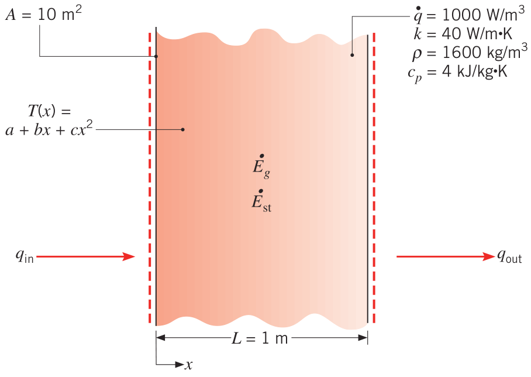

## Required:

Determine the rate of heat transfer entering and leaving the wall at $x=0\ \mathrm{m}$ and $x=1\ \mathrm{m}$, respectively. Determine the rate of change of energy storage in the wall. Determine the time rate of temperature change at $x=0\ \mathrm{m}$, $0.25\ \mathrm{m}$, and $0.5\ \mathrm{m}$

## Solution:

Start first by defining all of the given values.

$$L = 1\ \mathrm{m}$$
$$a = 800\ \mathrm{Δ°C}$$
$$b = -300\ \frac{\mathrm{Δ°C}}{\mathrm{m}}$$
$$c = -50\ \frac{\mathrm{Δ°C}}{\mathrm{m}^{2}}$$
$$\dot{q} = 1000\ \frac{\mathrm{W}}{\mathrm{m}^{3}}$$
$$A = 10\ \mathrm{m}^{2}$$
$$k = 40\ \frac{\mathrm{W}}{\left(\mathrm{K} \cdot \mathrm{m}\right)}$$
$$\rho = 1600\ \frac{\mathrm{kg}}{\mathrm{m}^{3}}$$
$$c_p = 4\ \frac{\mathrm{kJ}}{\left(\mathrm{K} \cdot \mathrm{kg}\right)}$$
$$x_{a_1} = 0\ \mathrm{m}$$
$$x_{a_2} = 1\ \mathrm{m}$$
$$x_{c_1} = 0\ \mathrm{m}$$
$$x_{c_2} = 0.25\ \mathrm{m}$$
$$x_{c_3} = 0.5\ \mathrm{m}$$

Looking at the system, it may be seen that it is 1D, an isotropic material, and has uniform heat generation. It may be seen that within the system, only conduction occurs. Thus the following expression is true for within the system.

$$q\left(x\right)=-kA \frac{\partial T}{\partial x}$$

Performing an surface energy balance of the left side, the rate of heat entering the wall may be found

$$\frac{dE_{sys}}{dt}=\Sigma \dot{E}_{in}-\Sigma \dot{E}_{out}$$

For a surface energy balance, the system term goes to zero.

$$0=\Sigma \dot{E}_{in}-\Sigma \dot{E}_{out}$$

The energy coming in is $q_{in}$ and the energy leaving is the conduction term at $x=0\ \mathrm{m}$. This is shown below.

$$0=q_{in}-q\left(x=0\ \mathrm{m}\right)$$

Solving for $q_{in}$ shows

$$q_{in}=q\left(x=0\ \mathrm{m}\right)=-kA \frac{\partial T}{\partial x}\Bigr\rvert_{x=0\ \mathrm{m}}=-kA \frac{\partial}{\partial x}\left( a+b x+c x^2\right)\Bigr\rvert_{x=0\ \mathrm{m}}=-kA \left(b+2c x\right)\Bigr\rvert_{x=0\ \mathrm{m}}$$

Answer (a1): $q_{in} = -k A (b + 2 c x)\Bigr\rvert_{x=0\ \mathrm{m}} = 120.0\ \mathrm{kW}$

A similar expression may be derived for the right side to determine $q_{out}$. This is shown below.

Answer (a2): $q_{out} = q\left(x=1\ \mathrm{m}\right) = -k A (b + 2 c x)\Bigr\rvert_{x=1\ \mathrm{m}} = 160.0\ \mathrm{kW}$

Using 1st Law for the entire system

$$\frac{dE_{sys}}{dt}=\Sigma \dot{E}_{in} - \Sigma \dot{E}_{out}$$

The energy stored in the system will be the left hand side.

$$\dot{E}_{st}=\frac{dE_{sys}}{dt}$$

The energy coming into the system is due to $q_{in}$ and the generation term. Thus

$$\Sigma \dot{E}_{in}=q_{in}+A L \dot{q}$$

The energy leaving the system is due to $q_{out}$. Thus

$$\Sigma \dot{E}_{out}=q_{out}$$

The overall energy balance then gives the overall energy storage rate of change in the wall which is

Answer (b): $\dot{E}_{st} = q_{in}+A L \dot{q}-q_{out} = -30.0\ \mathrm{kW}$

To find the time rate of change of the temperature at any point in the medium the heat diffusion equation (HDE) can be used. Beginning with the full HDE.

$$\frac{\partial}{\partial x}\left(k \frac{\partial T}{\partial x}\right)+\frac{\partial}{\partial y}\left(k \frac{\partial T}{\partial y}\right)+\frac{\partial}{\partial z}\left(k \frac{\partial T}{\partial z}\right)+\dot{q}=\rho c_p \frac{\partial T}{\partial t}$$

Since the system is 1D, the HDE becomes

$$\frac{\partial}{\partial x}\left(k \frac{\partial T}{\partial x}\right)+\dot{q}=\rho c_p \frac{\partial T}{\partial t}$$

Since the material is isotropic, the HDE becomes

$$k \frac{\partial^2 T}{\partial x^2}+\dot{q}=\rho c_p \frac{\partial T}{\partial t}$$

Solving for the time rate of change of the temperature shows

$$\frac{\partial T}{\partial t}=\frac{k}{\rho c_p}\frac{\partial^2 T}{\partial x^2}+\frac{\dot{q}}{\rho c_p}$$

Inspecting the simplified expression, it may be seen that the only unknown is the second partial derivative of temperature with respect to $x$ position. This may be found since the temperature distribution is known. The first partial derivative was found previous. Thus the second partial derivative is then

$$\frac{\partial^2 T}{\partial x^2}=\frac{\partial}{\partial x}\left(\frac{\partial T}{\partial x}\right)=\frac{\partial}{\partial x}\left( b+2 c x\right)=2c$$

The time rate of change of the temperature at a point of interest is then

$$\frac{\partial T}{\partial t}=\frac{k}{\rho c_p}\left(2c\right)+\frac{\dot{q}}{\rho c_p}$$

Since the expression above has no dependence on position, the time rate of change of temperature will be the same for all given positions within the material.

Answer (c): $\frac{\partial T}{\partial t} = \frac{k}{\rho c_p}\left(2 c\right)+\frac{\dot{q}}{\rho c_p} = -4.6875E-04\ \frac{\mathrm{K}}{\mathrm{s}}$